# UAS Visualisasi Dataa

Muhammad Taufiq Hidayat-A3202300042

2025-01-27

```r
library(readr)
library(readxl)
library(gganimate)
Data<- read_xlsx("Data.xlsx")
```

# Tahapan Pembuatan Grafik

## 1. Persiapan Data

- Pastikan data sudah bersih dan sesuai kebutuhan.
- Jika perlu, lakukan agregasi atau transformasi data menggunakan fungsi seperti aggregate()

## 2. Impor Pustaka

- Impor pustaka yang dibutuhkan seperti ggplot2 untuk visualisasi dan pustaka tambahan (contoh: gganimate)

## 3. Inisialisasi Grafik

- Gunakan fungsi ggplot() sebagai dasar pembuatan grafik. Masukkan data dan tetapkan estetika (aesthetic mapping) menggunakan aes()

## 4. Tambahkan Geometri

- Pilih tipe grafik yang sesuai dengan menggunakan fungsi geometri:
- Bar chart: geom_bar(stat = “identity”)
- Scatter plot: geom_point()
- Line chart: geom_line()
- Histogram: geom_histogram()
- Box plot: geom_boxplot()

## 5. Tambahkan Label dan Judul

- Gunakan fungsi labs() untuk menambahkan judul grafik, serta label sumbu X dan Y

## 6. Atur Tema

- Sesuaikan tampilan grafik menggunakan fungsi tema, seperti:
- theme_minimal() # Tema sederhana
- theme_classic() # Tema klasik
- theme(plot.title = element_text(hjust = 0.5, size = 16))

## 7. Customisasi Tambahan

- Tambahkan elemen tambahan, seperti:
- Skala warna: scale_fill_gradient() atau scale_color_manual()
- Batas nilai sumbu: ylim() atau xlim()
- Format angka: scales::comma untuk angka ribuan

## 8. Tambahkan Animasi

- Jika ingin membuat grafik interaktif atau animasi, gunakan pustaka seperti gganimate:
- transition_time(variabel_waktu)
- ease_aes(‘linear’)

# 1.Grafik Univariat (Histogram)

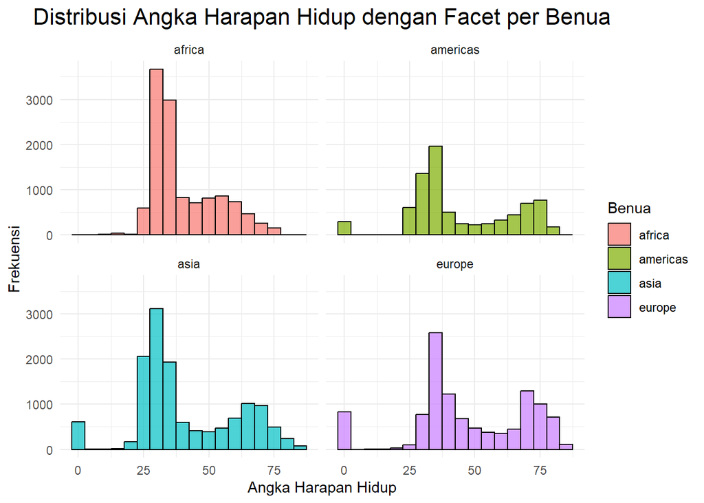

```r
facet_histogram <- ggplot(Data, aes(x = Angka_Harapan_Hidup, fill = Benua)) +
#memasukkan data ke x yaitu angka harapan hidup
#fill = benua : pemberian warna ke masing-masing benua

  geom_histogram(binwidth = 5, color = "black", alpha = 0.7) +
#binwidth = 5: Lebar tiap bin (kelompok) adalah 5
#fill = "skyblue": Warna isi histogram.
#color = "black": Warna garis tepi histogram.
#alpha = 0.7: Transparansi warna histogram.

  labs(
    title = "Distribusi Angka Harapan Hidup dengan Facet per Benua",#Judul
    x = "Angka Harapan Hidup",#nama sumbu x
    y = "Frekuensi" #nama sumbu y
  )+

  theme_minimal() + #Tema minimalis untuk tampilan yang bersih.
  facet_wrap(~ Benua) + #membuat grafik tepisah
  theme(plot.title = element_text(hjust = 0.5, size = 16))
#hjust = 0.5 mengatur judul grafik agar terpusat secara horizontal
#size = 16 mengubah ukuran font judul

# Tampilkan histogram dengan facet
facet_histogram
```

# 2. Grafik Bivariat (Scatter plot)

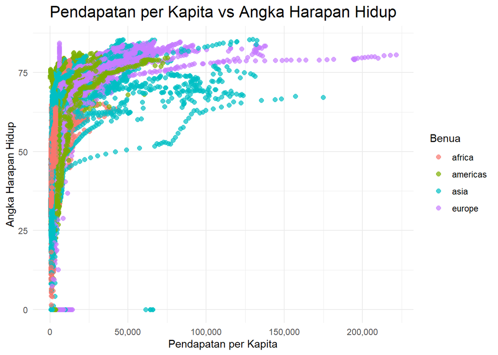

```r
# Scatter plot sederhana
scatter_plot_simple <- ggplot(Data, aes(x = Pendapatan_per_kapita, y = Angka_Harapan_Hidup, color = Benua)) +
#memasukkan data ke x yaitu pendapatan per kapita
#memasukkan data ke y yaitu angka harapan hidup
#color = benua : pemberian warna ke masing-masing benua

  geom_point(size = 2, alpha = 0.7) +
#size = 2 : ukuran point/titik menjadi 2
#alpha = 0.7 mengatur tingkat transparansi titik-titik tersebut

  labs(
    title = "Pendapatan per Kapita vs Angka Harapan Hidup", #judul
    x = "Pendapatan per Kapita", #nama sumbu x
    y = "Angka Harapan Hidup" #nama sumbub y
  )+

  theme_minimal() + #Tema minimalis untuk tampilan yang bersih
  theme(plot.title = element_text(hjust = 0.5, size = 16)) +
#theme() mengatur elemen-elemen tema lebih lanjut
#hjust = 0.5 memastikan judul grafik terpusat secara horizontal
#size = 16 mengatur ukuran font judul grafik

  scale_x_continuous(labels = scales::comma)
#scale_x_continuous() digunakan untuk mengatur format label pada sumbu X
#scales::comma digunakan untuk format angka dengan pemisah ribuan

# Tampilkan scatter plot
scatter_plot_simple
```

# 3. Grafik Multivariat (Heatmap)

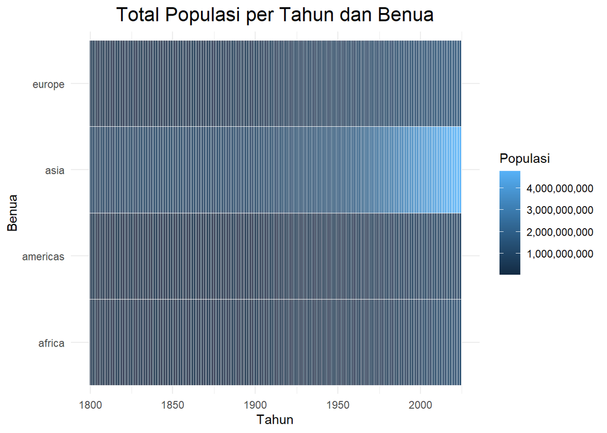

```r
# Hitung total Populasi per Tahun dan Benua
data_heatmap2 <- aggregate(Populasi ~ Tahun + Benua, Data, sum)
#aggregate()untuk menghitung total Populasi per kombinasi Tahun dan Benua
#data_heatmap2 untuk menyimpan hasil aggregate
#sum digunakan untuk menjumlahkan nilai populasi berdasarkan kombinasi kategori tahun dan benua

# Heatmap Populasi
heatmap2 <- ggplot(data_heatmap2, aes(x = Tahun, y = Benua, fill = Populasi)) +
#ggplot() digunakan untuk memulai pembuatan heatmap
#memasukkan data ke x yaitu tahun
#memasukkan data ke y yaitu benua
#fill = populasi pengisian warna berdasarkan populasi

  geom_tile(color = "white") +
#geom_tile() menggambarkan kotak-kotak yang membentuk heatmap
#color = "white" memberi warna ptih untuk batas pada kotak-kotak tersebut

  labs(
    title = "Total Populasi per Tahun dan Benua", #judul
    x = "Tahun", #nama sumbu x
    y = "Benua" #nama sumbu y
  )+

  theme_minimal() + #Tema minimalis untuk tampilan yang bersih.
  theme(plot.title = element_text(hjust = 0.5, size = 16)) +
#theme() mengatur elemen-elemen tema lebih lanjut
#hjust = 0.5 memastikan judul grafik terpusat secara horizontal
#size = 16 mengatur ukuran font judul grafik

  scale_fill_continuous(labels = scales::comma)  # Format angka pada legenda
#scale_x_continuous() digunakan untuk mengatur format label pada sumbu X
#scales::comma digunakan untuk format angka dengan pemisah ribuan

# Tampilkan heatmap
heatmap2
```